# inclass-week5

Author

Ziyang Ye

### Activity 1

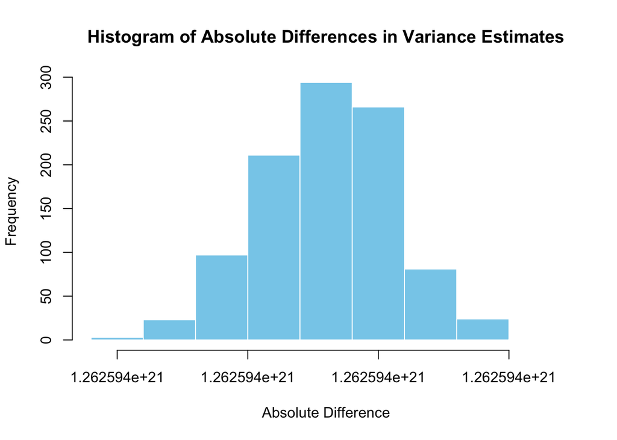

```r
set.seed(12345)


n1 <- 100
n2 <- 100
reps <- 1000


abs_diff <- numeric(reps)

for (i in 1:reps) {
  x1 <- rnorm(n1, mean = 1e-6, sd = 1e-2)
  x2 <- rnorm(n2, mean = 1e12, sd = 1e2)
  x <- c(x1, x2)
  n <- length(x)
  var_builtin <- var(x)
  var_manual <- (sum(x^2) / (n - 1)) - ((sum(x) / (n - 1))^2)
  abs_diff[i] <- abs(var_builtin - var_manual)
}

hist(abs_diff,
     main = "Histogram of Absolute Differences in Variance Estimates",
     xlab = "Absolute Difference",
     col = "skyblue",
     border = "white")
```

### Activity 2

For a $p$-dimensional random vector $\mathbf{X}$ following the standard multivariate Normal distribution,
$$\mathbf{X} \sim N(\mathbf{0}_p, \mathbf{I}_p),$$
the transformation
$$\mathbf{Y} = \mathbf{S}^\top \mathbf{X}$$
is claimed to yield a new random vector $\mathbf{Y}$ with covariance matrix
$$\operatorname{Cov}(\mathbf{Y}) = \mathbf{S}^\top \mathbf{S} = \mathbf{\Sigma}.$$

## Proof of the Statement

1. **Mean of $\mathbf{Y}$:**

   Since
   $$\mathbf{X} \sim N(\mathbf{0}_p, \mathbf{I}_p),$$
   we have
   $$\mathbb{E}[\mathbf{X}] = \mathbf{0}_p.$$
   Then,
   $$\mathbb{E}[\mathbf{Y}] = \mathbb{E}[\mathbf{S}^\top \mathbf{X}] = \mathbf{S}^\top \mathbb{E}[\mathbf{X}] = \mathbf{S}^\top \mathbf{0}_p = \mathbf{0}_p.$$
2. **Covariance of $\mathbf{Y}$:**

   The covariance matrix of $\mathbf{Y}$ is given by
   $$\operatorname{Cov}(\mathbf{Y}) = \mathbb{E}\left[(\mathbf{Y} - \mathbb{E}[\mathbf{Y}])(\mathbf{Y} - \mathbb{E}[\mathbf{Y}])^\top\right].$$
   Since $\mathbb{E}[\mathbf{Y}] = \mathbf{0}_p$, this simplifies to
   $$\operatorname{Cov}(\mathbf{Y}) = \mathbb{E}\left[\mathbf{Y}\mathbf{Y}^\top\right].$$

   $$\operatorname{Cov}(\mathbf{Y}) = \mathbb{E}\left[\mathbf{S}^\top \mathbf{X}\mathbf{X}^\top \mathbf{S}\right] = \mathbf{S}^\top \, \mathbb{E}\left[\mathbf{X}\mathbf{X}^\top\right] \mathbf{S}.$$
   Since $\operatorname{Cov}(\mathbf{X}) = \mathbf{I}_p$, we have
   $$\mathbb{E}\left[\mathbf{X}\mathbf{X}^\top\right] = \mathbf{I}_p.$$
   Therefore,
   $$\operatorname{Cov}(\mathbf{Y}) = \mathbf{S}^\top \mathbf{I}_p \mathbf{S} = \mathbf{S}^\top \mathbf{S} = \mathbf{\Sigma}.$$

This shows that $\mathbf{Y}$ follows a multivariate Normal distribution with covariance matrix $\mathbf{\Sigma}$.

## Two Methods to Factorize $\mathbf{\Sigma}$

Assuming that $\mathbf{\Sigma}$ is positive definite, here are two standard factorization methods:

### 1. Cholesky Decomposition

$$\mathbf{\Sigma} = \mathbf{L} \mathbf{L}^\top,$$

where $\mathbf{L}$ is a lower triangular matrix with positive diagonal entries. If we set

$$\mathbf{S}^\top = \mathbf{L} \quad \text{or equivalently} \quad \mathbf{S} = \mathbf{L}^\top,$$

then the transformation $\mathbf{Y} = \mathbf{S}^\top \mathbf{X}$ produces a random vector with covariance $\mathbf{\Sigma}$.

### 2. Spectral Decomposition

$$\mathbf{\Sigma} = \mathbf{U} \mathbf{\Lambda} \mathbf{U}^\top,$$

where $\mathbf{U}$ is an orthogonal matrix whose columns are the eigenvectors of $\mathbf{\Sigma}$, $\mathbf{\Lambda}$ is a diagonal matrix containing the positive eigenvalues of $\mathbf{\Sigma}$.

Define the square root of the diagonal matrix as $\mathbf{\Lambda}^{1/2}$. Then we can write

$$\mathbf{\Sigma} = \mathbf{U} \mathbf{\Lambda}^{1/2} \mathbf{\Lambda}^{1/2} \mathbf{U}^\top = \left( \mathbf{\Lambda}^{1/2} \mathbf{U}^\top \right)^\top \left( \mathbf{\Lambda}^{1/2} \mathbf{U}^\top \right).$$

we obtain the desired factorization.

### Activity 3

```r
data <- read.csv("regression.csv")
mod <- lm(y ~ ., data = data)
X <- model.matrix(mod)
y <- data$y

beta_lm <- coef(mod)
beta_inv <- solve(t(X) %*% X) %*% t(X) %*% y
beta_solve <- solve(t(X) %*% X, t(X) %*% y)
U <- chol(t(X) %*% X)
z <- solve(t(U), t(X) %*% y)
beta_chol <- solve(U, z)

norm_inv <- sum(abs(beta_lm - beta_inv))
norm_solve <- sum(abs(beta_lm - beta_solve))
norm_chol <- sum(abs(beta_lm - beta_chol))

print(norm_inv)
```

```
[1] 5.965346e-05
```

```r
print(norm_solve)
```

```
[1] 2.776718e-07
```

```r
print(norm_chol)
```

```
[1] 1.224205e-07
```

### Activity 4

```r
X <- as.matrix(data[ , -1])
X_centered <- scale(X, center = TRUE, scale = FALSE)

# Eigendecomposition of the covariance matrix
cov_mat <- cov(X_centered)
eigen_decomp <- eigen(cov_mat)
A1 <- eigen_decomp$vectors

# Method 2: Singular Value Decomposition (SVD) of the centered X matrix
svd_decomp <- svd(X_centered)
A2 <- svd_decomp$v

# Adjust signs for comparison (eigenvectors are unique up to sign)
for(j in 1:ncol(A1)) {
  if(sum(A1[, j] * A2[, j]) < 0)
    A2[, j] <- -A2[, j]
}

# Compute the Frobenius norm of the difference between A1 and A2
norm_diff <- norm(A1 - A2, type = "F")
print(norm_diff)
```

```
[1] 0.06917381
```